# Effects of user characterestics on the Duration of the Trip

## Investigation Overview

> In this investigation, I wanted to look at the features of the trip that may predict its duration. I mainly focused on the age, type and gender of the users.

## Dataset Overview

> This data set includes information about individual rides made in a bike-sharing system covering the greater San Francisco Bay area. There are 174,952 trips in the dataset with information about when and where the trip started and ended, the duration of each trip, and some information about the users (type, gender, birth year).

## Distribution of Trip Duration

The trip duration takes a very large range of values, from about 61 seconds at the lowest, to more than 84,000 seconds at the highest. When I used a logarithmic scale, the distribution appeared unimodal.

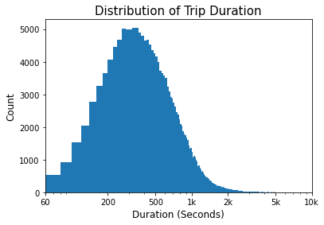

## Distibution of the Age of the Users

most users are 20-40 years old.

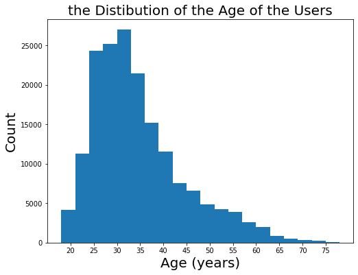

## Duration vs. Age

the duration of the trip appears to be inversely related to the age of the user.

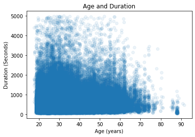

## Duration vs. User Type

Plotting duration on a logarithmic scale, customers tend to have longer trips than subscribers.

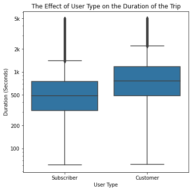

## Duration vs. Gender

Plotting duration on a logarithmic scale, males appear to have shorter trips than other genders.

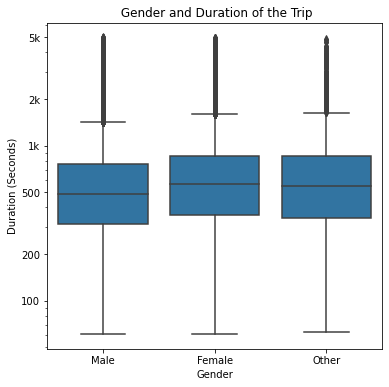

## No features appear to strengthen or weaken the relationship between the duration of the trip and the age of the user.

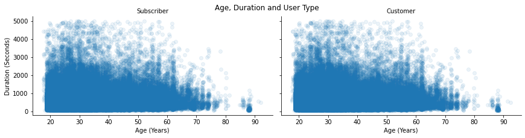

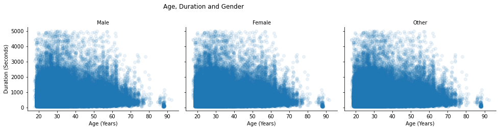

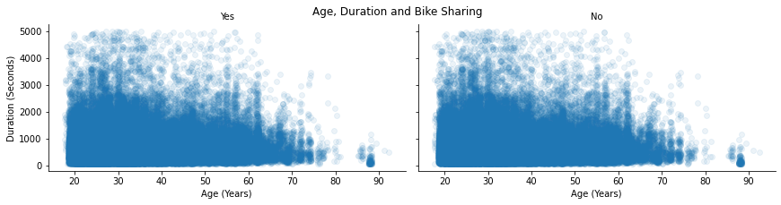

## The Longest 20 Trips from the Start Station to the End Station

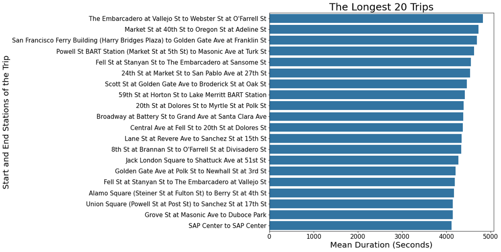

## The Shortest 20 Trips from the Start Station to the End Station

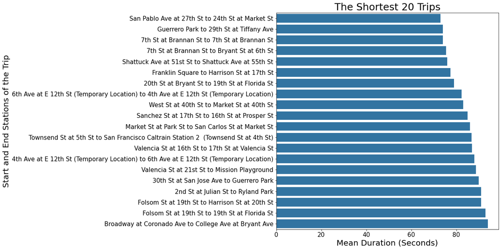

## Distribution of the Start Hour of the Trip

The most common periods of the day when trips start are 7-9 am and 4-6 pm.

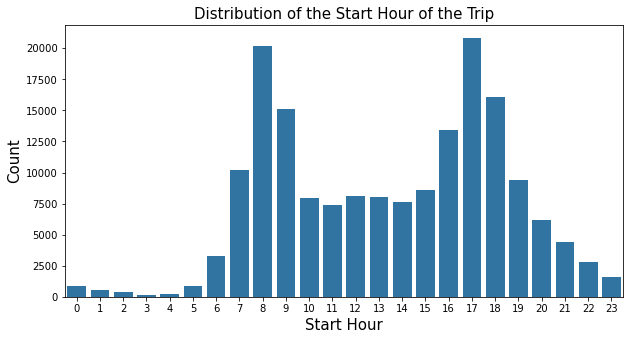